# ECON621: Describing Relationships Between Variables, Numerically and Graphically

Adam Gorski

Jan. 9, 2020

Today’s Lecture:

- Single Variable Visualizations
- Visualizing Relationships between Multiple Variables
- `ggplot2`

Oftentimes, the best way to communicate with your data, especially to a broader audience, is with visualizations. R and R Studio are great for creating and scaling robust data visualizations. Base R has some functions that will allow you to create basic visuals quickly and with minimal required data manipulation. The `ggplot2` package allows you to produce more elegant visuals that would be appropriate for sharing externally. However, `ggplot2` requires some data manipulation and a different coding syntax. Both base R and `ggplot2` are great tools for exploratory data analysis as well.

### Single Variable Visualizations

##### Bar Graph

For category variables, a straightforward way to visualize the data is with a bar graph. Generally, there is a bar for each category, and the height (or size) of each bar is based on the count (or frequency) of the category. You already know how to get the underlying data with the `table` function.

```r
table(wine_data$wine_type)
```

```
##
##   Red  Rose White
##    19     3     3
```

The `barplot` function requires count data (not a vector of text), so you can give it the results of the table function.

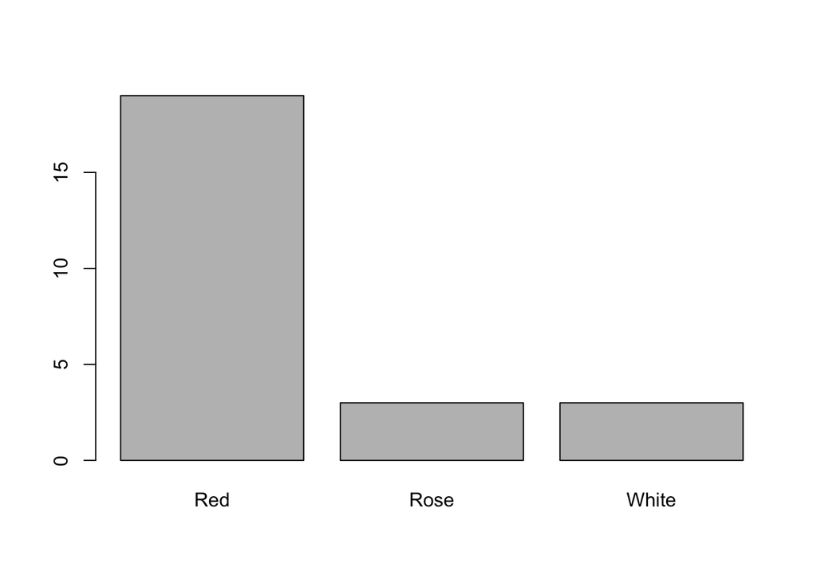

```r
barplot(table(wine_data$wine_type))
```

`barplot` has lots of arguments you can modify to change the characteristics of your output. Use `?barplot` to explore the options.

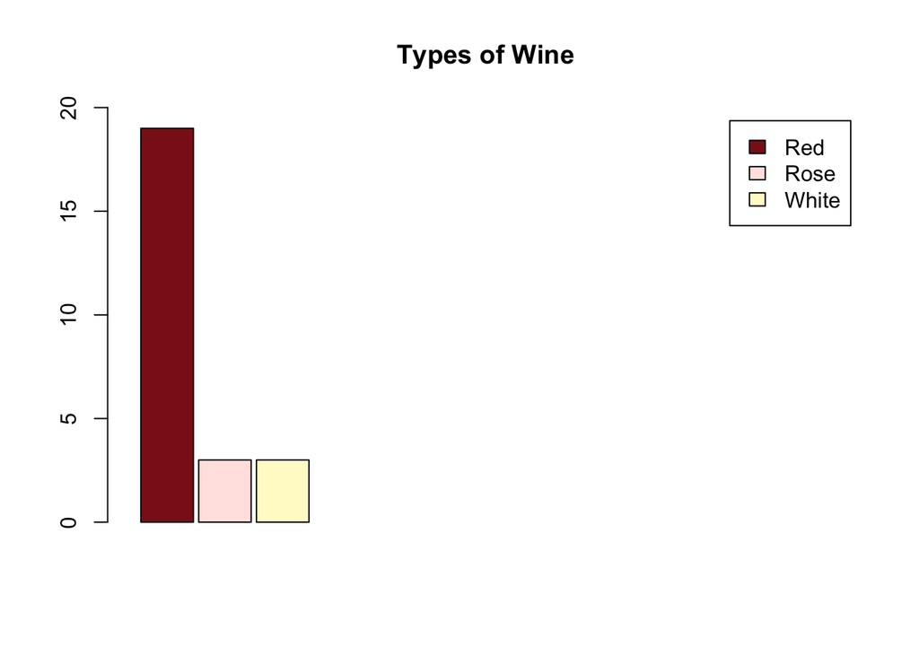

```r
barplot(table(wine_data$wine_type), main = "Types of Wine", width = 0.75,
        col = c("firebrick4", "mistyrose1", "lemonchiffon" ), space = 0.1,
        legend = row.names(table(wine_data$wine_type)), names.arg = F,
        xlim = c(0, 10), ylim = c(0, 20))
```

There is a functionally infinite number of iterations you can try. In my experience however, `barplot` is better for initial data exploration than for creating aesthetically appealing visuals.

##### Histogram

For continuous variables, one of the most common visuals is a histogram. A histogram is essentially a bar graph of frequencies, with each bar representing a ‘bin’ of values. A bin is a range of values (eg, all values between 10 and 19), and each bin holds a uniform-sized range. `hist` is the function for creating histogram, and the only required argument is a vector of values.

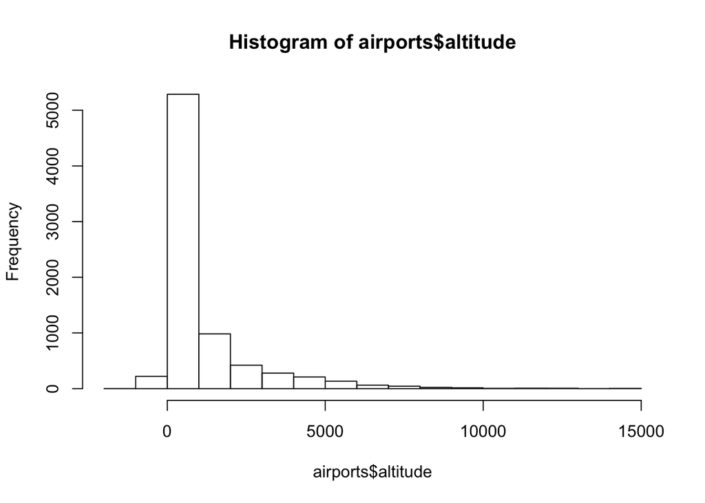

```r
hist(airports$altitude)
```

You can modify the number of bins with the `breaks` argument.

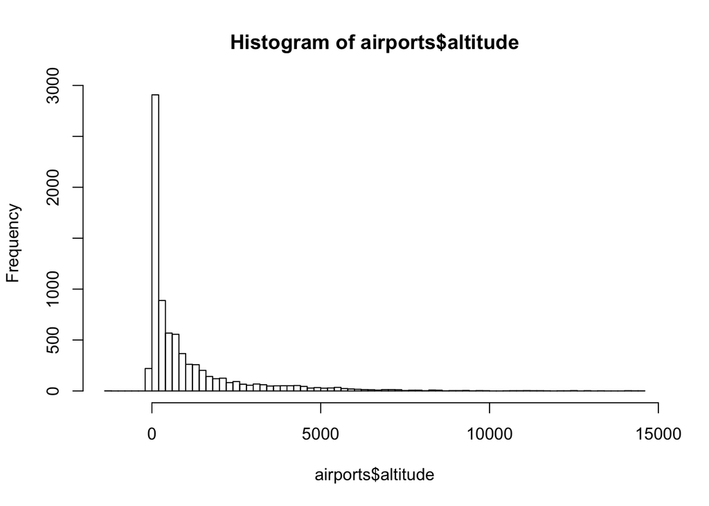

```r
hist(airports$altitude, breaks = 100)
```

```r
# We can see that the overwhelming majority of airports are at or near sealevel
```

You can also add lines to an existing plot with `abline`.

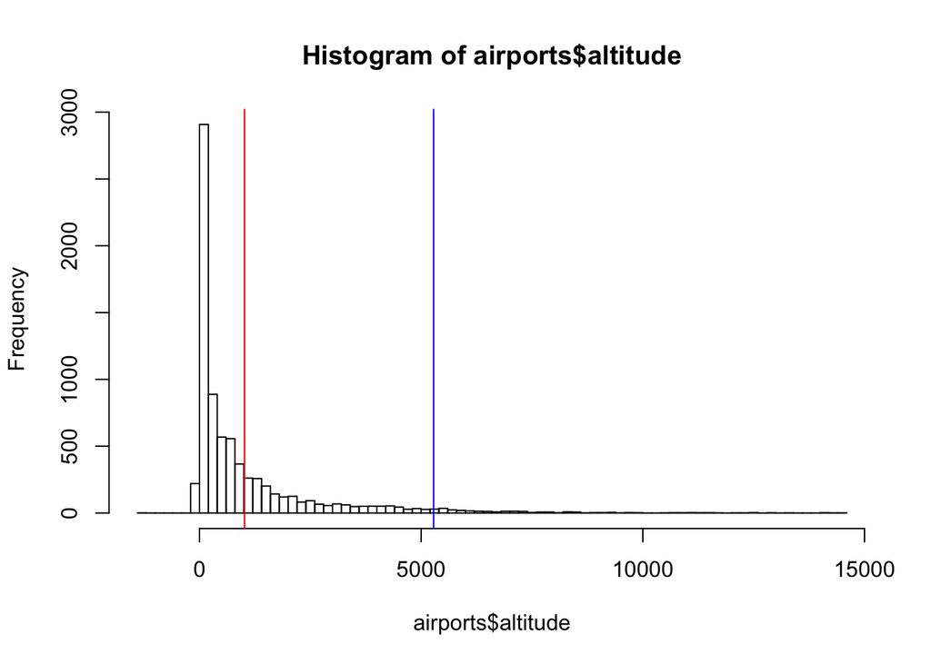

```r
# Add a red line for the mean altitude and a blue line for a mile high
hist(airports$altitude, breaks = 100)
abline(v = mean(airports$altitude), col = "red")
abline(v = 5280, col = "blue")
```

`hist` doesn’t have as many possible modifications as `barplot`, but you can modify its appearance. Look up `?hist` for options.

### Visualizing Relationships between Variables

Again, visuals in base R are designed for data exploration more so that aesthetics, and `plot` is no different. `plot` produces a scatterplot of values contained in two vectors.

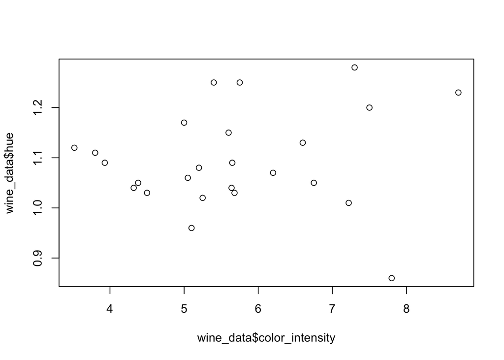

```r
plot(wine_data$color_intensity, wine_data$hue)
```

And again, you can modify the output in several ways, including adding reference lines.

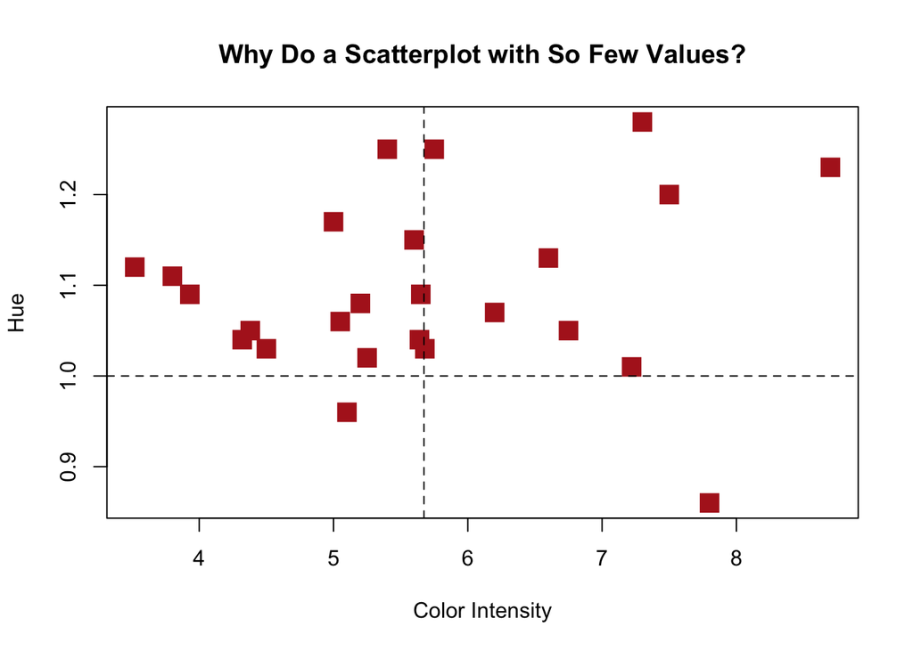

```r
plot(wine_data$color_intensity, wine_data$hue, xlab = "Color Intensity", ylab = "Hue",
     main = "Why Do a Scatterplot with So Few Values?", cex = 2, pch = 15, col = "firebrick")
abline(v = mean(wine_data$color_intensity), h = 1, lty = 2)
```

Looking at your scatterplot will give you an initial idea of the relationship between the two variables. You can define the relationship by calculating the correlation between the two variables with the `cor` function. You can add that value to your scatterplot as a legend. You can also add a best fit line for addtional context. You create a best fit line by running a single variable regression with `lm` inside of the `abline` function.

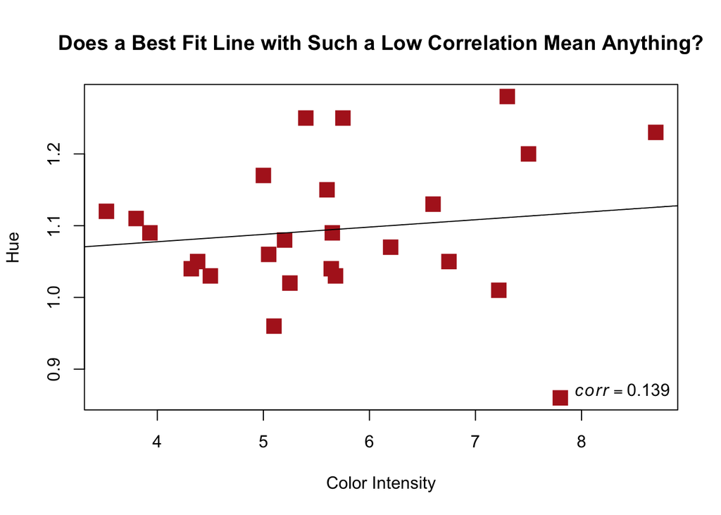

```r
plot(wine_data$color_intensity, wine_data$hue, xlab = "Color Intensity", ylab = "Hue",
     main = "Does a Best Fit Line with Such a Low Correlation Mean Anything?", cex = 2, pch = 15, col = "firebrick")
cor <- cor(wine_data$color_intensity, wine_data$hue)
mylabel = bquote(italic(corr) == .(format(cor, digits = 3)))
legend('bottomright', legend=mylabel, bty='n')
abline(lm(wine_data$hue ~ wine_data$color_intensity, data = wine_data), col = "black")
```

### Data Visualizations with `ggplot`

Visualizations with `ggplot` are better-looking and more robust than the ones above created with base R functions. To use `ggplot`, you need to install and load the `ggplot2` package.

```
install.packages("ggplot2")
```

```r
library(ggplot2)
```

The general structure for ggplot commands is: `ggplot(data=, aes(x=, y=), color=, size=,) + geom_xxxx()+geom_yyyy()`. The syntax of these commands requires these components:

- **Data**: a data.frame
- **Aes**thetics: How your data are represented visually, aka its “mapping”. Which variables are shown on x and y axes, as well as color, size, shape, etc.
- **Geom**etry: The geometric objects in a plot – points, lines, polygons, etc.

The key to understanding `ggplot2` is thinking about a data visualization in layers: just like you might do in an image editing program like *Photoshop*, *Illustrator*, or *Inkscape*. The `ggplot` function provides the data layer, and the subsequent `geom_` function(s) provide the visual layers.

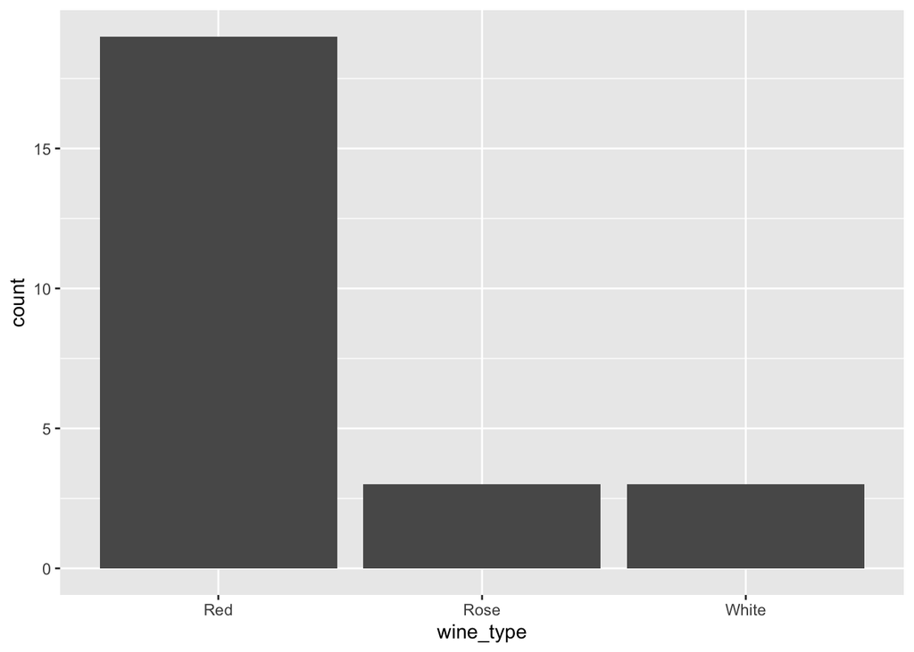

```r
ggplot(data = wine_data, aes(x = wine_type)) + geom_bar()
```

You can easily add a third dimension to the visual using `fill` or `color`, depending on the `geom` type.

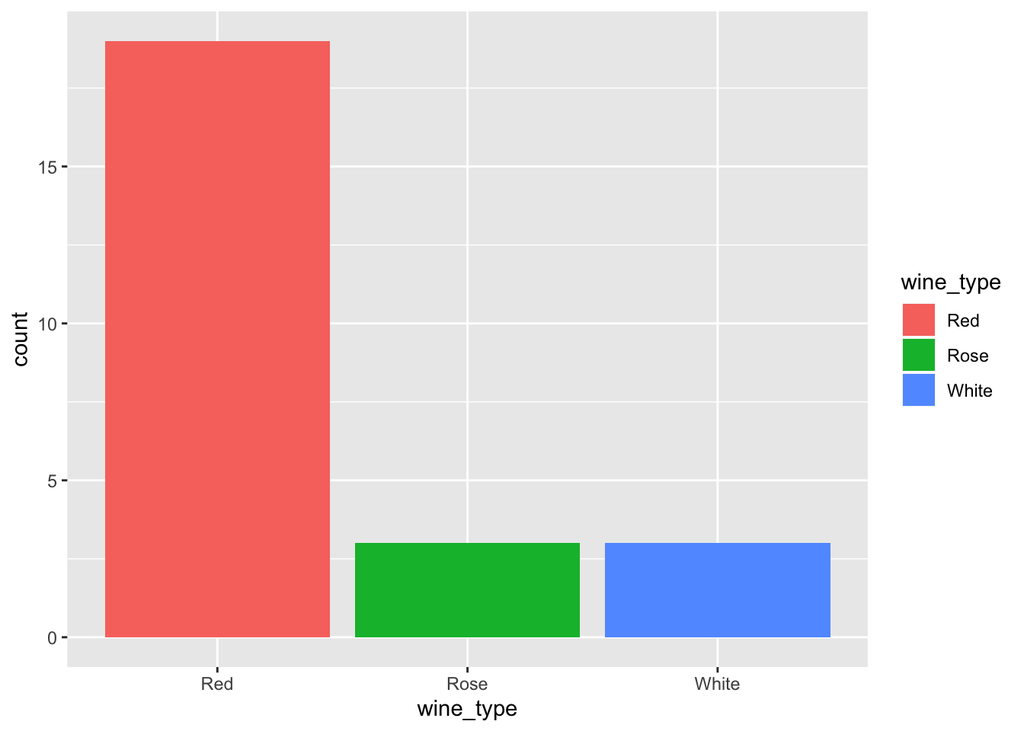

```r
ggplot(data = wine_data, aes(x = wine_type, fill = wine_type)) + geom_bar()
```

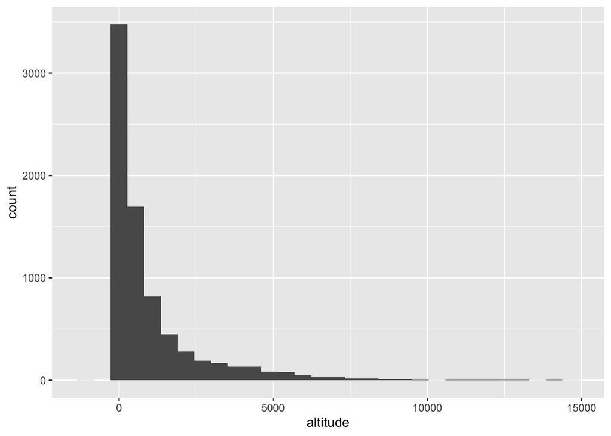

```r
ggplot(data = airports, aes(x = altitude)) + geom_bar(stat = "bin")
```

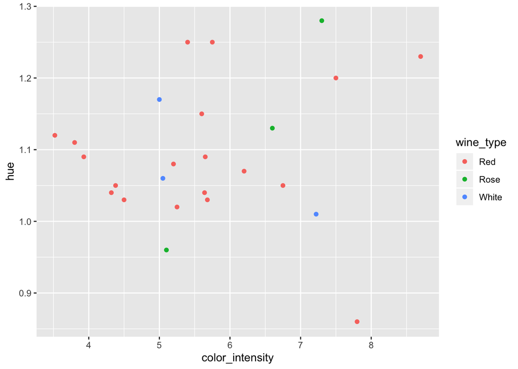

```r
ggplot(data = wine_data, aes(x = color_intensity, y = hue, color = wine_type)) + geom_point()
```

Labels and any other additional visual feature can be appended to the end of the command.

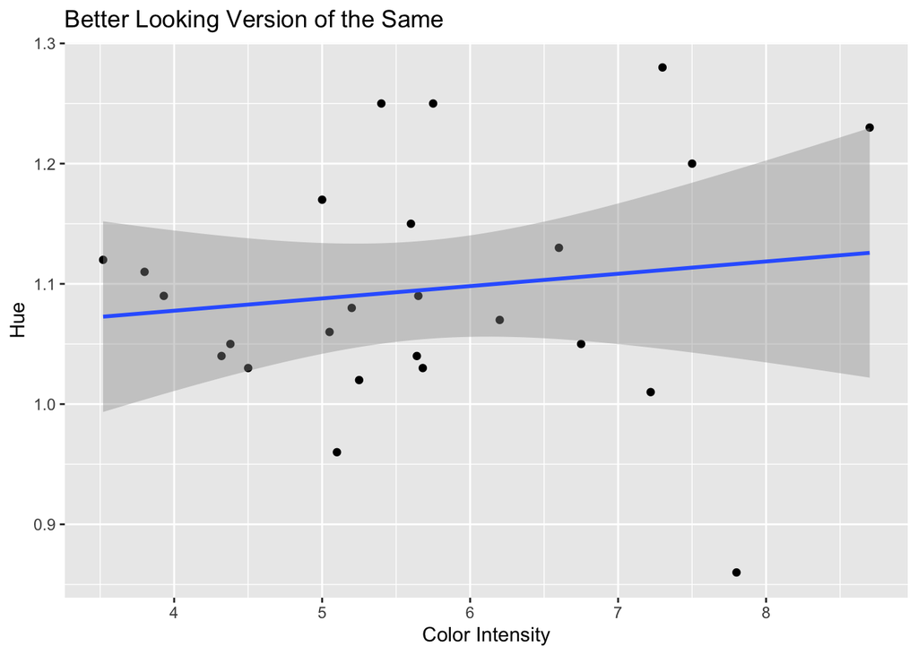

```r
ggplot(data = wine_data, aes(x = color_intensity, y = hue)) + geom_point() +
  xlab("Color Intensity") + ylab("Hue") + ggtitle("Better Looking Version of the Same") +
  geom_smooth(method="lm")
```

```r
# Note: in ggplot, the default for a best fit line includes the confidence intervals
```

`ggplot` is a great library with a lot of different visuals you can create, and we won’t cover all of them here. You can find several thorough guides, like [this one](http://r-statistics.co/ggplot2-Tutorial-With-R.html), online if you look.

Here we’ll cover three specific types of data representations in `ggplot`:

- Maps
- Time Series Data
- Heat Maps

##### Maps

If your data has location-specific data, like latitude and longitude coordinates, `ggplot` is great for making a map of your data.

It’s helpful to have additional location data. The packages `rnaturalearth` and `rnaturalearthdata` provide a map of countries of the entire world.

```
install.packages("rnaturalearth")
install.packages("rnaturalearthdata")
install.packages("rgeos") # Required to fix geo-alignment issue
```

```r
library(rnaturalearth)
library(rnaturalearthdata)
library(rgeos)
```

You then need to modify that data into something you can use in `ggplot`.

```r
world <- ne_countries(scale = "medium", returnclass = "sf")
```

You can make a simple map of the world with a `geom_sf` function and adjust the aesthetics the way you would any other `ggplot` visualization.

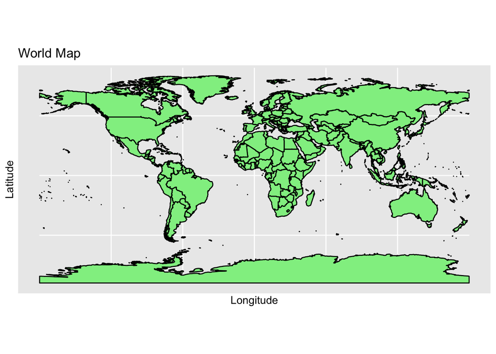

```r
ggplot(data = world) + geom_sf(color = "black", fill = "lightgreen") +
  xlab("Longitude") + ylab("Latitude") + ggtitle("World Map")
```

You can then add your data to the map as an additional `geom_point` layer.

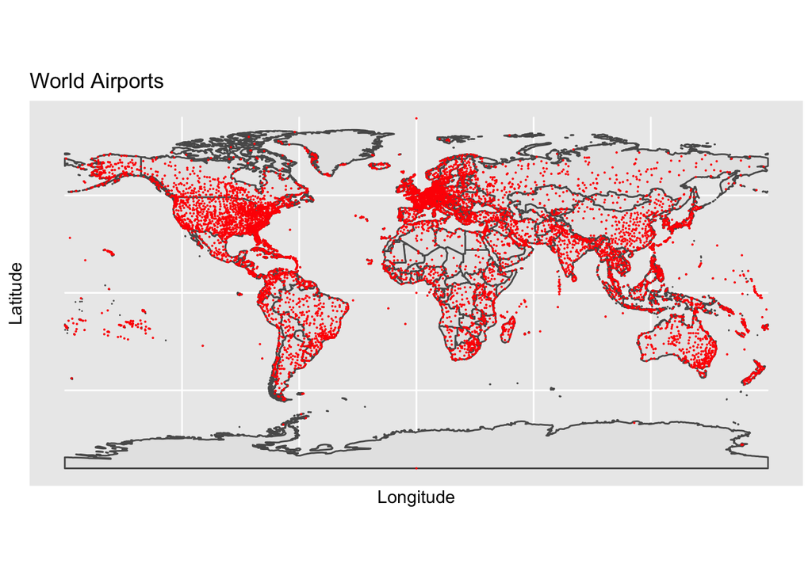

```r
ggplot(data = world) + geom_sf() +
  xlab("Longitude") + ylab("Latitude") + ggtitle("World Airports") +
  geom_point(data = airports, aes(x = longitude, y = latitude), size = .01, color = "red")
```

The extent of the map can also be set in `coord_sf`, in practice allowing to “zoom” in the area of interest, provided by limits on the x-axis (`xlim`), and on the y-axis (`ylim`).

Note: the limits are automatically expanded by a fraction to ensure that data and axes don’t overlap. It can also be turned off to exactly match the limits provided with `expand = FALSE`:

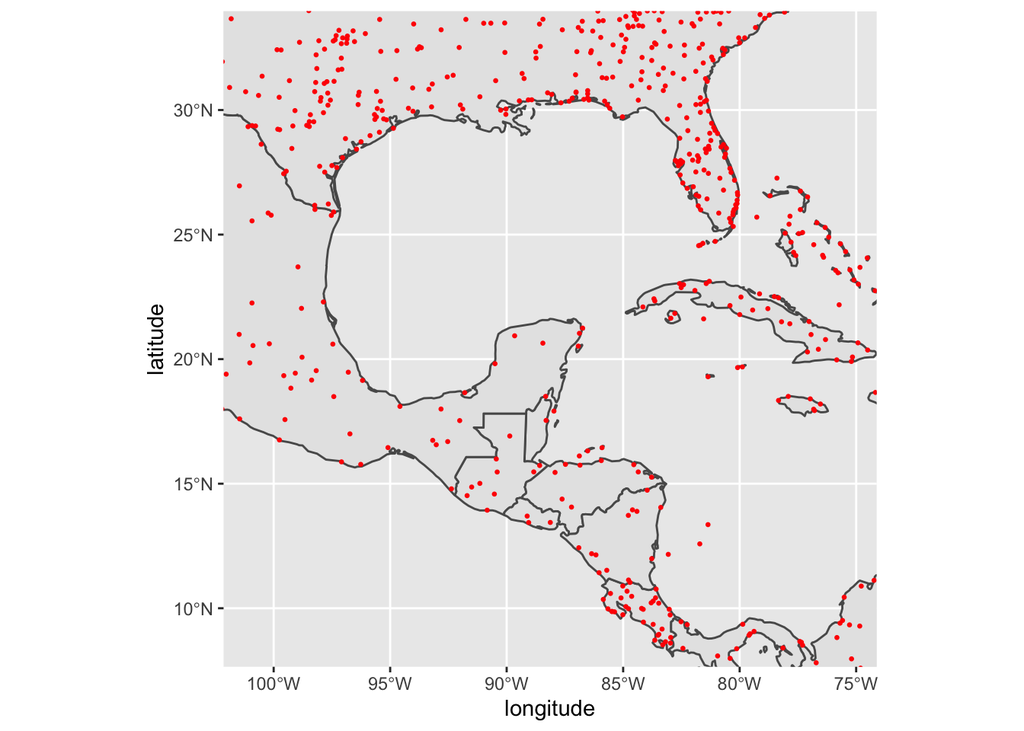

```r
ggplot(data = world) + geom_sf() +
    coord_sf(xlim = c(-102.15, -74.12), ylim = c(7.65, 33.97), expand = FALSE) +
    geom_point(data = airports, aes(x = longitude, y = latitude), size = 0.5, color = "red")
```

You can also add other data in your underlying dataset by changing the `fill` value by country (or region).

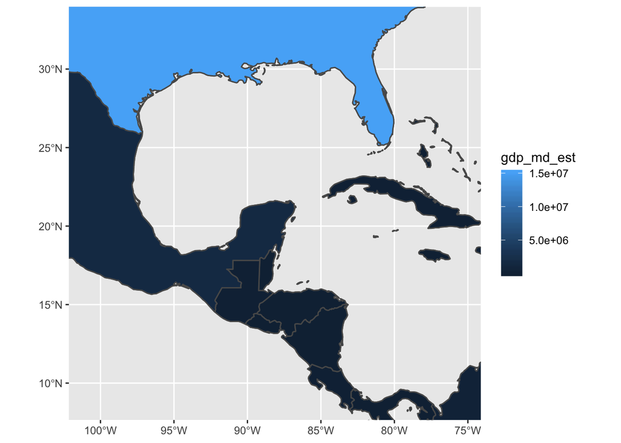

```r
ggplot(data = world) + geom_sf() + geom_sf(aes(fill = gdp_md_est)) +
    coord_sf(xlim = c(-102.15, -74.12), ylim = c(7.65, 33.97), expand = FALSE)
```

From here, it is relatively straightforward to merge in any other country-level data that you have and add it to your map.

##### Time Series Data

A common need for nearly any entity is understanding how variables are changing over time, and visualizations are great for communicating this type of data. There are many ways to visualize time series data. Here, we’ll cover two: bar plots and line graphs.

```r
# Simulate some daily usage data for different user types
data <- data.frame(user_type = c(rep("subscriber", 60), rep("trial", 60), rep("legacy", 60)),
                   total_activity = c(runif(60)*500, runif(60)*200, runif(60)*100),
                   day = rep(c(1:60), 3))
head(data)
```

```
##    user_type total_activity day
## 1 subscriber       99.67300   1
## 2 subscriber      299.62449   2
## 3 subscriber       30.70496   3
## 4 subscriber      106.04562   4
## 5 subscriber      185.61721   5
## 6 subscriber      253.40677   6
```

```r
# Note: the shape of this data is long. If we had received this data wide, ie, a column for days 1 - 60, we would need to melt it long to create this visual
```

You can create a stacked bar plot to show the the total value and the proportions in each category. In `geom_bar`, set the `position` argument to `"stack"`.

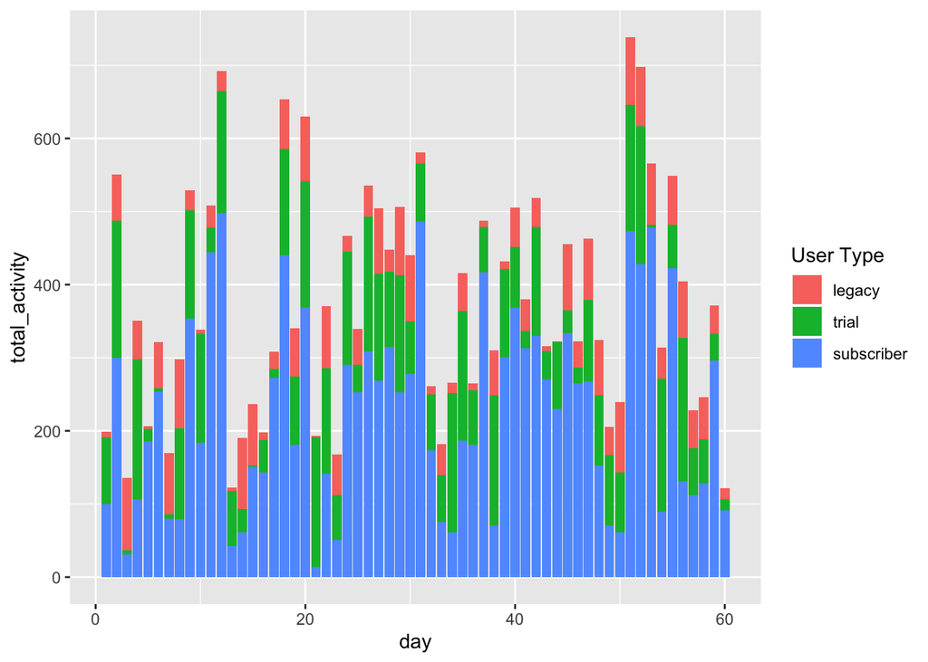

```r
ggplot(data, aes(fill = factor(user_type, levels = c("legacy", "trial", "subscriber")),
                 y = total_activity, x = day)) +
  geom_bar(position = "stack", stat = "identity") + labs(fill = "User Type")
```

```r
# If we want to know what user patterns have looked like over the past 60 days, a stacked bar graph conveys a lot of information, but it is difficult to get a sense for the proportion of user types
```

To show the proportion of the total belonging to each category, switch `position` to `fill`.

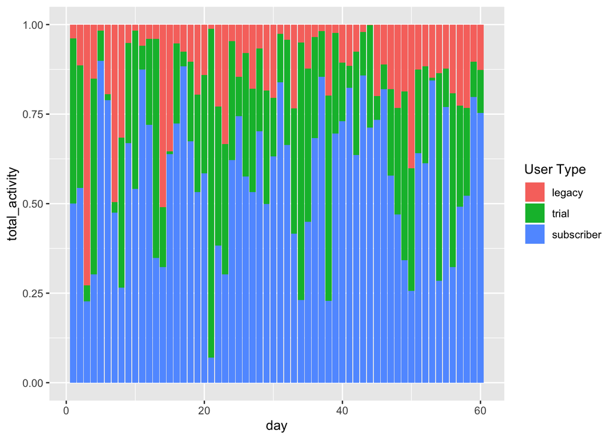

```r
ggplot(data, aes(fill = factor(user_type, levels = c("legacy", "trial", "subscriber")),
                 y = total_activity, x = day)) +
  geom_bar(position = "fill", stat = "identity") + labs(fill = "User Type")
```

A different way to display the same time series data is with a line graph. Inside the `ggplot` components, you’ll need to change `fill` to `group`. Swap out `geom_bar` for `geom_line` (and add `geom_point` for clarity).

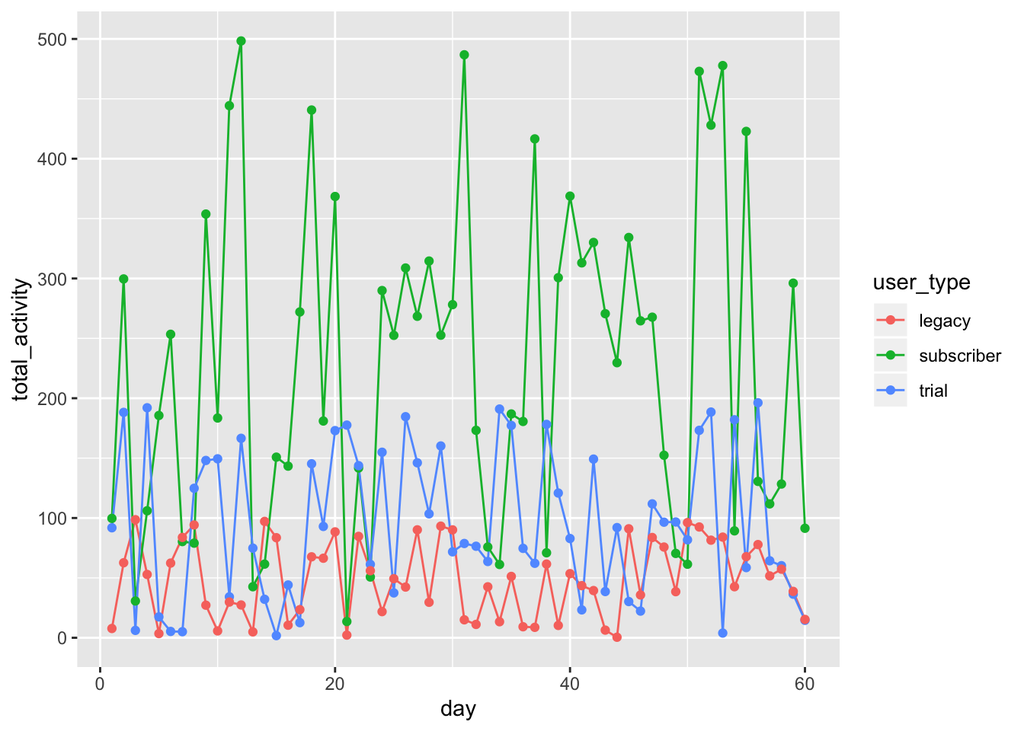

```r
ggplot(data, aes(group = user_type, y = total_activity, x = day)) +
  geom_line(aes(color = user_type)) + geom_point(aes(color = user_type))
```

##### Heat Maps

Heat maps are a useful for visualizing the amount of overlap between two variables, especially category variables. You can think of heat maps as a way to more clearly represent data from the `table` function.

The data you need for a heat map is a three column structure. The first two columns are the variables you’re interested in, and the third column is the percent of column one given column two. For example, consider a dataframe on children and snacks. The first row is: `Julia`, `Apple Slice`, `65%`, which means that 65% of the snacks that Julia consumes are apple slices.

However, data often doesn’t arrive in the exact shape you need for your visualization. Perhaps the data is just a list of events that have happened, so you will need to find counts and percentages of counts.

```r
# Simulate some criminal justice data on arbitrators and decision reached
data <- data.frame(arbitrator = rep(c("A", "B", "C", "D", "E"), 50),
                   decision = round(runif(250) * 10))
head(data)
```

```
##   arbitrator decision
## 1          A        9
## 2          B        3
## 3          C        7
## 4          D        6
## 5          E        3
## 6          A        6
```

```r
# Convert the table function results to a dataframe
counts <- data.frame(table(data$arbitrator, data$decision))
head(counts)
```

```
##   Var1 Var2 Freq
## 1    A    0    1
## 2    B    0    3
## 3    C    0    3
## 4    D    0    1
## 5    E    0    2
## 6    A    1    6
```

```r
# Need to add the total count of cases for each arbitrator to calculate the %
counts <- data.frame(counts, data.frame(table(data$arbitrator))[2])
# Calculate the % for each arbitrator
counts$percentage <- counts$Freq/counts$Freq.1 * 100
head(counts)
```

```
##   Var1 Var2 Freq Freq.1 percentage
## 1    A    0    1     50          2
## 2    B    0    3     50          6
## 3    C    0    3     50          6
## 4    D    0    1     50          2
## 5    E    0    2     50          4
## 6    A    1    6     50         12
```

```r
# Now we have our proportion data
```

To create your heat map, you’ll use `geom_tile` for the visual layer. `ggplot` also makes it easy to add text to each tile with the percentages and to customize how you scale the colors of the tiles.

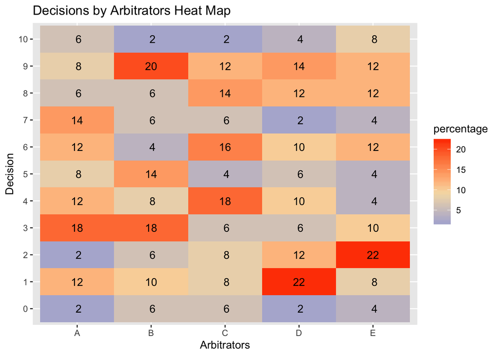

```r
ggplot(data = counts, aes(x = Var1, y = Var2)) + geom_tile(aes(fill = percentage)) +
  scale_fill_gradient2(high = "orangered", mid = "wheat", low = "cornflowerblue", midpoint = mean(counts$percentage)) +
  geom_text(aes(label = format(counts$percentage,digits = 2))) +
  xlab("Arbitrators") + ylab("Decision") + ggtitle("Decisions by Arbitrators Heat Map")
```

You will need to spend time to develop comfort with these tools and to find styles you like. Keep in mind that data visualizations are often for other stakeholders, so knowing how to handle modifications is nearly as important as creating the visual in the first place.

Beyond that, try to think about how your visualizations would handle dynamic data, ie, data that is updated regularly. There is real demand for this skill, because it allows you to hand off the visual you built to someone else, and they can check on it whenever they want to information on the metrics involved. This is usually accomplished with a modular, or standalone, script that has a built in connection to a database. Everytime your client refreshes the visualization, the data is re-pulled and the visualization refreshed.

#### Acknowledgement

This lesson is based in part on:

- Rochelle Terman’s *Computational Tools for Social Science* course materials
- Mel Moreno and Mathieu Basille’s *Drawing beautiful maps programmatically with R, sf and ggplot2*